# Assignment 11b - HTML Tables Submit Assignment

Damilare Olaleye

11/8/2018

```r
library(tidyverse)
library(stringr)
```

PART 1

The webpage http://www.goodcarbadcar.net/2017/01/usa-2016-auto-brand-sales-results-rankings/ (Links to an external site.) contains car sales for 2016 and 2015 for the major automakers.

1. Collect the 2016 and 2015 sales for five manufacturers.

2015,2016 : Mazda, Infiniti, Lexus, Fiat, Subaru

2. Create a html page containing (1) a sentence or two sentences introducing the data, and (2) a single html table with this sales data for the five manufacturers. (Your table will have six rows and three columns.) Make sure that this html page displays fine using a web browser.
3. Upload your html page to your personal website. https://raw.githubusercontent.com/olalede/RStudio-3430/master/Assignment_11b_website.html
4. Read your html page into R.

```r
sales_data <- readLines("https://raw.githubusercontent.com/olalede/RStudio-3430/master/Assignment_11b_website.html")
```

5. Using character manipulation commands, get the data from your html page into a data frame. Display your data frame to make sure that it contains clean data.

```r
test_d <- sales_data[grep("td", sales_data)]
test_d2 <- gsub('<td>|</td>', '', test_d)
str_remove_all(test_d2, "<b>|</b>") -> test_d2
d3 <- matrix((test_d2[-c(1:3)]), 5, 3, byrow = T)
d4 <- data.frame(d3)
colnames(d4) <- c("Automaker", "sales_2015", "sales_2016")
d4
```

```
##   Automaker sales_2015 sales_2016
## 1     Mazda     319183     297773
## 2  Infiniti     133498     138293
## 3     Lexus     344601      73861
## 4      Fiat      42922      32742
## 5    Subaru     582675     615132
```

6. Compute the percentage increase in sales for your five manufacturers.

```r
d4$Automaker <- as.character(d4$Automaker)
d4$sales_2015 <- as.numeric(as.character(d4$sales_2015))
d4$sales_2016 <- as.numeric(as.character(d4$sales_2016))
d4 %>% mutate(Increase = round((((sales_2016 - sales_2015)/sales_2015)*100), 2)) -> d4
d4
```

```
##   Automaker sales_2015 sales_2016 Increase
## 1     Mazda     319183     297773    -6.71
## 2  Infiniti     133498     138293     3.59
## 3     Lexus     344601      73861   -78.57
## 4      Fiat      42922      32742   -23.72
## 5    Subaru     582675     615132     5.57
```

7. Using ggplot, construct a graph where the manufacturer names are on the vertical scale and the percentage increases on the horizontal scale.

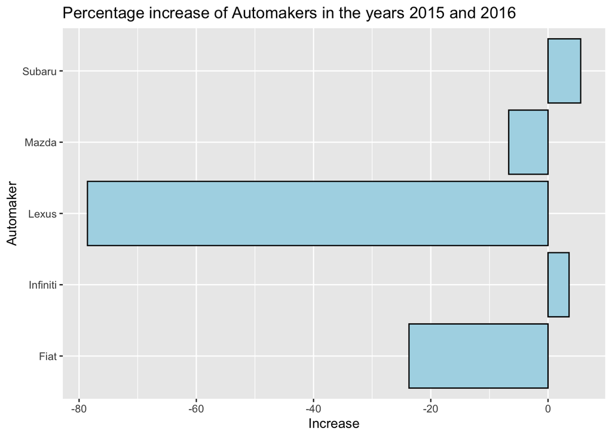

```r
ggplot(d4) + geom_col(aes(Automaker, Increase), fill = "light blue", color = "black") + coord_flip() + ggtitle("Percentage increase of Automakers in the years 2015 and 2016")
```

PART 2

1. Find a “top-10” table on a html page. Read this html page into R.

```r
table_page <- readLines("https://www.worldatlas.com/articles/the-10-largest-cities-in-the-world.html")
```

2. Using character manipulation functions, create a data frame with this top-10 information.

```r
table_data <- table_page[461:464]
str_replace_all(table_data, "<td>|</td>", " ") -> table_data
str_remove_all(table_data, "<tbody>|</tbody>") -> table_data
str_remove_all(table_data, "</tr>|<tr>") -> table_data
str_remove_all(table_data, "<thead>|</thead>") -> table_data
str_replace_all(table_data, "</th>|<th>", " ") -> table_data
str_remove_all(table_data, "<table data-role=\"table\">") -> table_data
str_remove_all(table_data, "\\$") -> table_data
str_remove_all(table_data, ",") -> table_data
str_remove_all(table_data, "�") -> table_data
table_data <- unlist(str_split(table_data, "  "))
table_data <- table_data[nchar(table_data) > 0]

table_matrix <- matrix((table_data[-c(1:4)]), 10, 4, byrow = T)
table_df <- data.frame(table_matrix)
colnames(table_df) <- c("Rank", "City", "Country", "Population")

table_df$Rank <- as.numeric(as.character(table_df$Rank))
table_df$City <- as.character(table_df$City)
table_df$Country <- as.character(table_df$Country)
table_df$Population <- as.numeric(as.character(table_df$Population))

head(table_df, 10)
```

```
##    Rank City Country Population
## 1    NA <NA>    <NA>         NA
## 2    NA <NA>    <NA>         NA
## 3    NA <NA>    <NA>         NA
## 4    NA <NA>    <NA>         NA
## 5    NA <NA>    <NA>         NA
## 6    NA <NA>    <NA>         NA
## 7    NA <NA>    <NA>         NA
## 8    NA <NA>    <NA>         NA
## 9    NA <NA>    <NA>         NA
## 10   NA <NA>    <NA>         NA
```

3. Construct a good graph of this top-10 data.

[figure not shown]

```r
ggplot(head(table_df, 10)) +
  geom_bar(stat = "identity", fill = "light pink", color = "grey1", aes(x = reorder(City, Population), y = Population/1000000)) +
  ggtitle("Top 10 Largest Cities by Population") +
  ylab("Population in millions") +
  xlab("Country") +
  coord_flip()
```